# Self-Driving Car Engineer Nanodegree

## Project: Build a Traffic Sign Recognition Classifier

In this notebook, a template is provided for you to implement your functionality in stages, which is required to successfully complete this project. If additional code is required that cannot be included in the notebook, be sure that the Python code is successfully imported and included in your submission if necessary.

In addition to implementing code, there is a writeup to complete. The writeup should be completed in a separate file, which can be either a markdown file or a pdf document. There is a [write up template](https://github.com/udacity/CarND-Traffic-Sign-Classifier-Project/blob/master/writeup_template.md) that can be used to guide the writing process. Completing the code template and writeup template will cover all of the [rubric points](https://review.udacity.com/#!/rubrics/481/view) for this project.

The [rubric](https://review.udacity.com/#!/rubrics/481/view) contains "Stand Out Suggestions" for enhancing the project beyond the minimum requirements. The stand out suggestions are optional. If you decide to pursue the "stand out suggestions", you can include the code in this Ipython notebook and also discuss the results in the writeup file.

> **Note:** Code and Markdown cells can be executed using the **Shift + Enter** keyboard shortcut. In addition, Markdown cells can be edited by typically double-clicking the cell to enter edit mode.

## Step 0: Load The Data

```python
import pickle
import matplotlib.pyplot as plt
import tensorflow as tf
import numpy as np
from sklearn.utils import shuffle
from sklearn.preprocessing import normalize
import matplotlib.cm as cm
import cv2
from multiprocessing import Process

EPOCHS = 30
BATCH_SIZE = 128
datalist = []
labellist = []
```

## Functions

```python
# Obj: Sandardise input to between 0 and 1
def Standardise(x_data):
    x_data = cv2.normalize(x_data, None, alpha=0, beta=1, norm_type=cv2.NORM_MINMAX, dtype=cv2.CV_32F)
    return x_data


# Obj: Scale images
def Scale(img):
    width, height = img.shape[:2]
    scl = np.random.randint(-3, 3)

    src = np.float32([[0, 0], [width, 0], [0, height], [width, height]])
    dst = np.float32([[scl, scl], [width - scl, scl], [scl, height - scl], [width - scl, height - scl]])

    M = cv2.getPerspectiveTransform(src, dst)
    img = cv2.warpPerspective(img, M, (width, height))
    return img


# Obj: Randomly warp the image
def Warp(img):
    width, height = img.shape[:2]
    topleft = np.random.randint(0, 3, 2)
    topright = [width - np.random.randint(0, 3), np.random.randint(0, 3)]
    bottomleft = [np.random.randint(0, 3), height - np.random.randint(0, 3)]
    bottomright = [width - np.random.randint(0, 3), height - np.random.randint(0, 3)]

    src = np.float32([[0, 0], [height, 0], [0, width], [height, width]])
    dst = np.float32([topleft, topright, bottomleft, bottomright])
    M = cv2.getPerspectiveTransform(src, dst)
    img = cv2.warpPerspective(img, M, (width, height))
    return img


def Brighten(img):
    shift = img + 1.0
    imgmaxvalue = np.max(shift.flatten())
    max = 2.0 / imgmaxvalue
    min = max - 0.1
    coef = np.random.uniform(min, max)
    img = shift * coef - 1.0
    return img


# Obj: Randomly plots images. Used for comparison between original image and after applying transformations
def PlotRandomly(old, label, flag=False):
    randomindex = np.random.randint(0, len(old), 10)
    fig, axs = plt.subplots(2, 5, figsize=(15, 6))
    fig.subplots_adjust(hspace=.2, wspace=.001)
    axs = axs.ravel()
    for i in range(10):
        image = old[randomindex[i]]
        axs[i].axis('off')
        axs[i].imshow(image)
        axs[i].set_title(label[randomindex[i]])


# Obj: Simply plots the input image with its label
def PlotSimple(imgarr, label, rows, columns, flag=False):
    fig, axs = plt.subplots(rows, columns)
    fig.subplots_adjust(hspace=.2, wspace=.001)
    axs = axs.ravel()
    for i in range(rows * columns):
        image = imgarr[i]
        axs[i].axis('off')
        if flag:
            axs[i].imshow(image, cmap=cm.gray)
        else:
            axs[i].imshow(image)
        axs[i].set_title(label[i])
    plt.show()


# Obj: Applies all transformations
def newimg(img):
    img = Warp(img)
    img = Scale(img)
    #     img = Brighten(img)
    img = np.rint(img)
    return img


# Obj: Draw histogram to visualise number of exmples in each class
def drawhist(labels):
    classes = np.unique(labels)
    num, bins = np.histogram(labels, len(classes))
    centre = (bins[:-1] + bins[1:]) / 2
    plt.bar(centre, num, align='center')
    plt.show()
    print("Max num of Examples = ", np.max(num))
    print("Min num of Examples = ", np.min(num))
    print("Avg num of Examples = ", np.average(num))
    return


def processimage(xdata, labels, i, num):
    labelind = np.nonzero(labels == i)[0]
    k = 0
    j = 0
    count = 800 - num[i]
    outdata = np.empty([count, 32, 32, 1])
    outlabels = np.empty(count)
    while j < (800 - num[i]):
        outdata[j] = np.expand_dims(newimg(xdata[labelind[k]]), axis=2)
        outlabels[j] = i
        j += 1
        k += 1
        if k == len(labelind):
            k = 0
    datalist.append(outdata)
    labellist.append(outlabels)
    return


def convgrayscale(imgarr):
    return np.sum(imgarr / 3, axis=3, keepdims=True)


def uniformBrightness(imgarr):
    imgarr = imgarr.astype('uint8')
    count = len(imgarr)
    for i in range(count):
        img = imgarr[i]
        clahe = cv2.createCLAHE(clipLimit=2.0, tileGridSize=(8, 8))
        img = clahe.apply(img)
        imgarr[i] = np.expand_dims(img, axis=2)
    return imgarr


# Obj: Generate data for classes with less examples:
def Generatedata(xdata, labels):
    num, bins = np.histogram(labels, len(np.unique(labels)))  # nim stores the value of each label
    genind = np.nonzero(num < 800)[0]  # genind stores the label of those classes with insuffucuent num of examples
    #     print(len(np.nonzero(labels == 1)[0]))
    #     print(len(np.nonzero(labels == 2)[0]))
    for i in range(0, len(genind)):
        processimage(xdata, labels, genind[i], num)
    for i in datalist:
        xdata = np.concatenate((xdata, i))
    for i in labellist:
        labels = np.concatenate((labels, i))
    drawhist(labels)
    np.save('PreprocessedData', xdata)
    np.save('PreprocessedLabels', labels)
```

## Step 1: Dataset Summary & Exploration

The pickled data is a dictionary with 4 key/value pairs:

- `'features'` is a 4D array containing raw pixel data of the traffic sign images, (num examples, width, height, channels).
- `'labels'` is a 1D array containing the label/class id of the traffic sign. The file `signnames.csv` contains id -> name mappings for each id.
- `'sizes'` is a list containing tuples, (width, height) representing the original width and height the image.
- `'coords'` is a list containing tuples, (x1, y1, x2, y2) representing coordinates of a bounding box around the sign in the image. **THESE COORDINATES ASSUME THE ORIGINAL IMAGE. THE PICKLED DATA CONTAINS RESIZED VERSIONS (32 by 32) OF THESE IMAGES**

Complete the basic data summary below. Use python, numpy and/or pandas methods to calculate the data summary rather than hard coding the results. For example, the [pandas shape method](http://pandas.pydata.org/pandas-docs/stable/generated/pandas.DataFrame.shape.html) might be useful for calculating some of the summary results.

### Provide a Basic Summary of the Data Set Using Python, Numpy and/or Pandas

```python
training_file = 'train.p'
validation_file = 'valid.p'
testing_file = 'test.p'

with open(training_file, mode='rb') as f:
    train = pickle.load(f)
with open(validation_file, mode='rb') as f:
    valid = pickle.load(f)
with open(testing_file, mode='rb') as f:
    test = pickle.load(f)

X_train, y_train = train['features'], train['labels']
X_valid, y_valid = valid['features'], valid['labels']
X_test, y_test = test['features'], test['labels']
# 'Old' is a copy of the original dataset provided to us.
oldXtrain = X_train
oldXvalid = X_valid
oldXtest = X_test
oldytrain = y_train
oldyvalid = y_valid
oldytest = y_test
# TODO: Number of training examples
n_train = y_train.shape[0]

# TODO: Number of validation examples
n_validation = y_valid.shape[0]

# TODO: Number of testing examples.
n_test = y_test.shape[0]

# TODO: What's the shape of an traffic sign imageNone
image_shape = X_train[0].shape

# TODO: How many unique classes/labels there are in the dataset.
n_classes = np.unique(y_train)
n_classes = n_classes.shape[0]

print("Number of training examples =", n_train)
print("Number of testing examples =", n_test)
print("Number of Validating examples = ", n_validation)
print("Image data shape =", image_shape)
print("Number of classes =", n_classes)
```

```
Number of training examples = 34799
Number of testing examples = 12630
Number of Validating examples =  4410
Image data shape = (32, 32, 3)
Number of classes = 43
```

### Include an exploratory visualization of the dataset

Visualize the German Traffic Signs Dataset using the pickled file(s). This is open ended, suggestions include: plotting traffic sign images, plotting the count of each sign, etc.

The [Matplotlib](http://matplotlib.org/) [examples](http://matplotlib.org/examples/index.html) and [gallery](http://matplotlib.org/gallery.html) pages are a great resource for doing visualizations in Python.

**NOTE:** It's recommended you start with something simple first. If you wish to do more, come back to it after you've completed the rest of the sections. It can be interesting to look at the distribution of classes in the training, validation and test set. Is the distribution the same? Are there more examples of some classes than others?

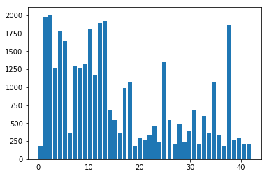

```
Max num of Examples =  2010
Min num of Examples =  180
Avg num of Examples =  809.279069767
```

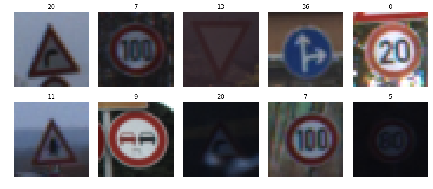

```python
drawhist(y_train)
PlotRandomly(X_train, y_train, True)
```

## Step 2: Design and Test a Model Architecture

Design and implement a deep learning model that learns to recognize traffic signs. Train and test your model on the [German Traffic Sign Dataset](http://benchmark.ini.rub.de/?section=gtsrb&subsection=dataset).

The LeNet-5 implementation shown in the classroom at the end of the CNN lesson is a solid starting point. You'll have to change the number of classes and possibly the preprocessing, but aside from that it's plug and play!

With the LeNet-5 solution from the lecture, you should expect a validation set accuracy of about 0.89. To meet specifications, the validation set accuracy will need to be at least 0.93. It is possible to get an even higher accuracy, but 0.93 is the minimum for a successful project submission.

There are various aspects to consider when thinking about this problem:

- Neural network architecture (is the network over or underfitting?)
- Play around preprocessing techniques (normalization, rgb to grayscale, etc)
- Number of examples per label (some have more than others).
- Generate fake data.

Here is an example of a [published baseline model on this problem](http://yann.lecun.com/exdb/publis/pdf/sermanet-ijcnn-11.pdf). It's not required to be familiar with the approach used in the paper but, it's good practice to try to read papers like these.

### Pre-process the Data Set (normalization, grayscale, etc.)

Minimally, the image data should be normalized so that the data has mean zero and equal variance. For image data, `(pixel - 128)/ 128` is a quick way to approximately normalize the data and can be used in this project.

Other pre-processing steps are optional. You can try different techniques to see if it improves performance.

Use the code cell (or multiple code cells, if necessary) to implement the first step of your project.

```
Original
```

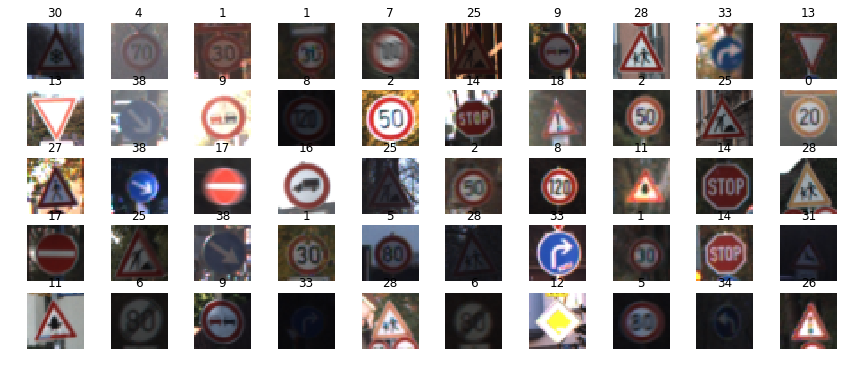

```
Grayscale
```

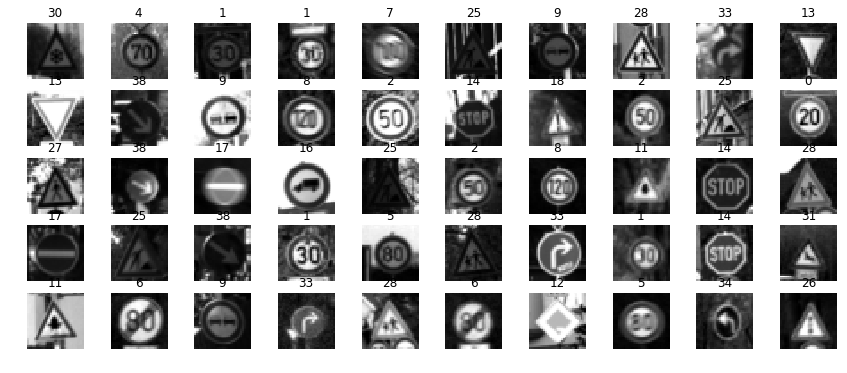

```
Uniform Histogram
```

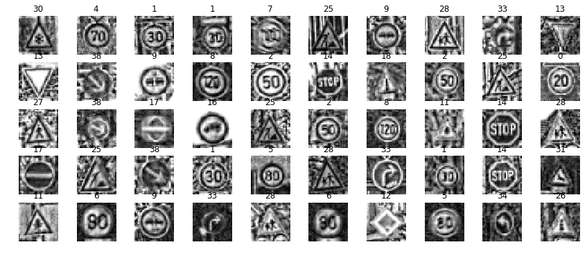

```
Sample of new data generated
```

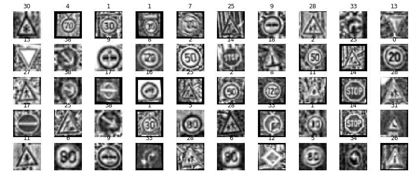

```python
def demonstrate():
    # Picking 50 images randomly
    randind = np.random.randint(0, len(y_train), 50)
    sample = X_train[randind]
    samplelab = y_train[randind]
    # Two functions below applied on entire dataset
    graysample = convgrayscale(sample)
    unifsample = uniformBrightness(graysample)

    # Plotting
    print('Original')
    PlotSimple(sample, samplelab, 5, 10)
    print('Grayscale')
    PlotSimple(graysample.squeeze(), samplelab, 5, 10, True)
    print('Uniform Histogram')
    PlotSimple(unifsample.squeeze(), samplelab, 5, 10, True)

    # function newimg is used to generate photos of classes with exmaples less than 800
    # demonstrating newimg by applying it on images from sample data
    newsample = np.empty_like(unifsample)
    for i in range(50):
        newsample[i] = np.expand_dims(newimg(unifsample[i]), axis=2)
    print('Sample of new data generated')
    PlotSimple(newsample.squeeze(), samplelab, 5, 10, True)
    return
demonstrate()
```

## Performing same function on the entire Dataset

```python
# X_train = convgrayscale(X_train)
# X_test = convgrayscale(X_test)
# X_valid = convgrayscale(X_valid)

# X_train = uniformBrightness(X_train)
# X_test = uniformBrightness(X_test)
# X_valid = uniformBrightness(X_valid)

# Generatedata(X_train, y_train)

# X_train = Standardise(X_train)
# X_test = Standardise(X_test)
# X_valid = Standardise(X_valid)
```

```python
X_train = np.load('PreprocessedData.npy')
y_train = np.load('PreprocessedLabels.npy')
X_test = convgrayscale(X_test)
X_valid = convgrayscale(X_valid)
X_test = uniformBrightness(X_test)
X_valid = uniformBrightness(X_valid)
X_train = Standardise(X_train)
X_test = Standardise(X_test)
X_valid = Standardise(X_valid)
print('done')
```

```
done
```

## Properties of data being fed into the Neural Network

```python
n_train = y_train.shape[0]

# TODO: Number of validation examples
n_validation = y_valid.shape[0]

# TODO: Number of testing examples.
n_test = y_test.shape[0]

# TODO: What's the shape of an traffic sign imageNone
image_shape = X_train[0].shape

# TODO: How many unique classes/labels there are in the dataset.
n_classes = np.unique(y_train)
n_classes = n_classes.shape[0]

print("Number of training examples =", n_train)
print("Number of testing examples =", n_test)
print("Number of Validating examples = ", n_validation)
print("Image data shape =", image_shape)
print("Number of classes =", n_classes)
```

```
Number of training examples = 46480
Number of testing examples = 12630
Number of Validating examples =  4410
Image data shape = (32, 32, 1)
Number of classes = 43
```

### Model Architecture

```python
def lenet(x):
    # Arguments used for tf.truncated_normal, randomly defines variables for the weights and biases for each layer
    mu = 0
    sigma = 0.1

    # TODO: Layer 1: Convolutional. Input = 32x32x1. Output = 28x28x6.
    l1w = tf.Variable(tf.truncated_normal(shape=(5, 5, 1, 6), mean=mu, stddev=sigma))
    l1b = tf.Variable(tf.zeros(6))
    l1 = tf.nn.conv2d(x, l1w, strides=[1, 1, 1, 1], padding='VALID') + l1b
    # TODO: Activation.
    l1 = tf.nn.relu(l1)
    # TODO: Pooling. Input = 28x28x6. Output = 14x14x6.
    out1 = tf.nn.max_pool(l1, ksize=[1, 2, 2, 1], strides=[1, 2, 2, 1], padding='VALID')

    # TODO: Layer 2: Convolutional. Output = 10x10x16.
    l2w = tf.Variable(tf.truncated_normal(shape=(5, 5, 6, 16), mean=mu, stddev=sigma))
    l2b = tf.Variable(tf.zeros(16))
    l2 = tf.nn.conv2d(out1, l2w, strides=[1, 1, 1, 1], padding='VALID') + l2b
    # TODO: Activation.
    l2 = tf.nn.relu(l2)
    # TODO: Pooling. Input = 10x10x16. Output = 5x5x16.
    out2 = tf.nn.max_pool(l2, ksize=[1, 2, 2, 1], strides=[1, 2, 2, 1], padding='VALID')

    # TODO: Layer 2b: Convolution. Input = 5x5x16. Output = 400
    l2bw = tf.Variable(tf.truncated_normal(shape=(5, 5, 16, 400), mean=mu, stddev=sigma))
    l2bb = tf.Variable(tf.zeros(400))
    l2b = tf.nn.conv2d(out2, l2bw, strides=[1, 1, 1, 1], padding='VALID') + l2bb
    # TODO: Activation
    out2b = tf.nn.relu(l2b)

    # TODO: Flatten. Input = 5x5x16. Output = 400.
    flatout = tf.contrib.layers.flatten(out2)
    out2b = tf.contrib.layers.flatten(out2b)

    outdrop = tf.concat([flatout, out2b], axis=1)
    outdrop = tf.nn.dropout(outdrop, prob)
    # TODO: Layer 3: Fully Connected. Input = 800. Output = 400.
    l3w = tf.Variable(tf.truncated_normal(shape=(800, 400), mean=mu, stddev=sigma))
    l3b = tf.Variable(tf.zeros(400))
    l3 = tf.matmul(outdrop, l3w) + l3b
    # TODO: Activation.
    out3 = tf.nn.relu(l3)

    # TODO: Layer 4: Fully Connected. Input = 400. Output = 200.
    l4w = tf.Variable(tf.truncated_normal(shape=(400, 200), mean=mu, stddev=sigma))
    l4b = tf.Variable(tf.zeros(200))
    l4 = tf.matmul(out3, l4w) + l4b
    # TODO: Activation.
    out4 = tf.nn.relu(l4)

    # TODO: Layer 5: Fully Connected. Input = 200. Output = 43.
    l5w = tf.Variable(tf.truncated_normal(shape=(200, 43), mean=mu, stddev=sigma))
    l5b = tf.Variable(tf.zeros(43))
    l5 = tf.matmul(out4, l5w) + l5b
    return l5
```

```python
x = tf.placeholder(tf.float32, (None, 32, 32, 1))
y = tf.placeholder(tf.int32, None)
one_hot_y = tf.one_hot(y, n_classes)
prob = tf.placeholder(tf.float32)

rate = 0.001
logits = lenet(x)
cross_entropy = tf.nn.softmax_cross_entropy_with_logits(labels=one_hot_y, logits=logits)
loss_operation = tf.reduce_mean(cross_entropy)
optimizer = tf.train.AdamOptimizer(learning_rate=rate)
training_operation = optimizer.minimize(loss_operation)
correct_prediction = tf.equal(tf.argmax(logits, 1), tf.argmax(one_hot_y, 1))
accuracy_operation = tf.reduce_mean(tf.cast(correct_prediction, tf.float32))
saver = tf.train.Saver()


# Obj: Evaluating the model
def evaluate(X_data, y_data):
    num_examples = len(X_data)
    total_accuracy = 0
    sess = tf.get_default_session()
    for offset in range(0, num_examples, BATCH_SIZE):
        batch_x, batch_y = X_data[offset:offset + BATCH_SIZE], y_data[offset:offset + BATCH_SIZE]
        accuracy = sess.run(accuracy_operation, feed_dict={x: batch_x, y: batch_y, prob: .75})
        total_accuracy += (accuracy * len(batch_x))
    return total_accuracy / num_examples


# Obj: Training the model
def trainer(X_train, y_train):
    with tf.Session() as sess:
        sess.run(tf.global_variables_initializer())
        num_examples = len(X_train)

        print("Training...")
        print()
        for i in range(EPOCHS):
            X_train, y_train = shuffle(X_train, y_train)
            for offset in range(0, num_examples, BATCH_SIZE):
                end = offset + BATCH_SIZE
                batch_x, batch_y = X_train[offset:end], y_train[offset:end]
                sess.run(training_operation, feed_dict={x: batch_x, y: batch_y, prob: .8})

            validation_accuracy = evaluate(X_valid, y_valid)
            print("EPOCH {} ...".format(i + 1))
            print("Validation Accuracy = {:.3f}".format(validation_accuracy))
            print()

        saver.save(sess, 'lenet')
        print("Model saved")


def evaluator():
    with tf.Session() as sess:
        saver.restore(sess, tf.train.latest_checkpoint('.'))

        test_accuracy = evaluate(X_test, y_test)
        print("Test Accuracy = {:.3f}".format(test_accuracy))
```

### Train, Validate and Test the Model

A validation set can be used to assess how well the model is performing. A low accuracy on the training and validation sets imply underfitting. A high accuracy on the training set but low accuracy on the validation set implies overfitting.

```python
trainer(X_train, y_train)
```

```
Training...

EPOCH 1 ...
Validation Accuracy = 0.877

EPOCH 2 ...
Validation Accuracy = 0.916

EPOCH 3 ...
Validation Accuracy = 0.920

EPOCH 4 ...
Validation Accuracy = 0.923

EPOCH 5 ...
Validation Accuracy = 0.922

EPOCH 6 ...
Validation Accuracy = 0.936

EPOCH 7 ...
Validation Accuracy = 0.941

EPOCH 8 ...
Validation Accuracy = 0.941

EPOCH 9 ...
Validation Accuracy = 0.940

EPOCH 10 ...
Validation Accuracy = 0.944

EPOCH 11 ...
Validation Accuracy = 0.951

EPOCH 12 ...
Validation Accuracy = 0.948

EPOCH 13 ...
Validation Accuracy = 0.957
```

[output cut: 38 more lines]

```
Validation Accuracy = 0.949

EPOCH 27 ...
Validation Accuracy = 0.954

EPOCH 28 ...
Validation Accuracy = 0.948

EPOCH 29 ...
Validation Accuracy = 0.950

EPOCH 30 ...
Validation Accuracy = 0.952

Model saved
```

```python
evaluator()
```

```
INFO:tensorflow:Restoring parameters from ./lenet
Test Accuracy = 0.933
```

## Step 3: Test a Model on New Images

To give yourself more insight into how your model is working, download at least five pictures of German traffic signs from the web and use your model to predict the traffic sign type.

You may find `signnames.csv` useful as it contains mappings from the class id (integer) to the actual sign name.

### Load and Output the Images

```python
import csv
```

```python
with open('signnames.csv') as csvfile:
    csvreader = list(csv.reader(csvfile, delimiter=','))
    classid = []
    signname = []
    for row in csvreader:
        classid.append(row[0])
        signname.append(row[1])
    classid.pop(0)
    signname.pop(0)
```

### Predict the Sign Type for Each Image

```python
newindlist = np.empty([43]).astype('int')
for i in range(43):
    a = np.nonzero(y_train == i)[0][0]
    newindlist[i] = a
oldtestimg = oldXtrain[newindlist]
testlabel = oldytrain[newindlist]
testimg = convgrayscale(oldtestimg)
testimg = uniformBrightness(testimg)
testimg = Standardise(testimg)
```

```python
def newevaluate(X_data, y_data):
    num_examples = len(X_data)
    total_accuracy = 0
    sess = tf.get_default_session()
    for offset in range(0, num_examples, BATCH_SIZE):
        batch_x, batch_y = X_data[offset:offset + BATCH_SIZE], y_data[offset:offset + BATCH_SIZE]
        accuracy = sess.run(accuracy_operation, feed_dict={x: batch_x, y: batch_y, prob: .75})
        total_accuracy += (accuracy * len(batch_x))
    return total_accuracy / num_examples
def newevaluator():
    with tf.Session() as sess:
        saver.restore(sess, tf.train.latest_checkpoint('.'))

        test_accuracy = newevaluate(testimg, testlabel)
        print("Test Accuracy = {:.3f}".format(test_accuracy))
newevaluator()
```

```
INFO:tensorflow:Restoring parameters from ./lenet
Test Accuracy = 1.000
```

```python
pred = tf.nn.softmax(logits)
def predictor(X_data, y_data):
    sess = tf.get_default_session()
    predictions = sess.run(tf.nn.softmax(logits), feed_dict={x: X_data, y: y_data, prob: .75})
    return predictions
def dopredictions(data, val):
    with tf.Session() as sess:
        saver.restore(sess, tf.train.latest_checkpoint('.'))
        predictions = predictor(data.astype('float'), val)
        return(predictions)
testpredicts = dopredictions(testimg, testlabel)
testpredicts = np.argmax(testpredicts, axis=1)
```

```
INFO:tensorflow:Restoring parameters from ./lenet
```

```python
signname = np.array(signname)
d = signname[testpredicts]
print(testimg.shape)
```

```
(43, 32, 32, 1)
```

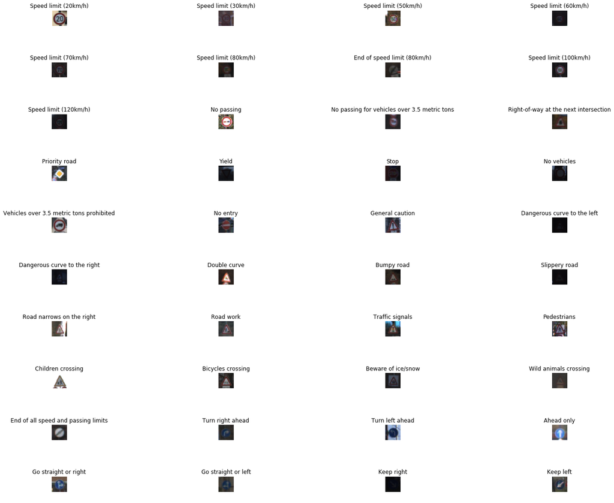

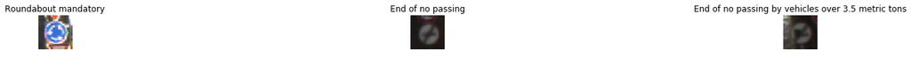

```python
def PlotMultiple(imgarr, label, rows, columns, flag=False):
    fig, axs = plt.subplots(rows, columns, figsize=(20,20))
    fig.subplots_adjust(hspace=.4, wspace=10)
    axs = axs.ravel()
    for i in range(rows * columns):
        image = imgarr[i]
        axs[i].axis('off')
        if flag:
            axs[i].imshow(image, cmap=cm.gray)
        else:
            axs[i].imshow(image)
        axs[i].set_title(label[i])
    plt.show()
PlotMultiple(oldtestimg[:40].squeeze(), d[:40], 10, 4, True)
PlotMultiple(oldtestimg[40:43].squeeze(), d[40:43], 1, 3, True)
```

### Output Top 5 Softmax Probabilities For Each Image Found on the Web

For each of the new images, print out the model's softmax probabilities to show the **certainty** of the model's predictions (limit the output to the top 5 probabilities for each image). [`tf.nn.top_k`](https://www.tensorflow.org/versions/r0.12/api_docs/python/nn.html#top_k) could prove helpful here.

The example below demonstrates how tf.nn.top_k can be used to find the top k predictions for each image.

`tf.nn.top_k` will return the values and indices (class ids) of the top k predictions. So if k=3, for each sign, it'll return the 3 largest probabilities (out of a possible 43) and the correspoding class ids.

Take this numpy array as an example. The values in the array represent predictions. The array contains softmax probabilities for five candidate images with six possible classes. `tf.nn.top_k` is used to choose the three classes with the highest probability:

```
# (5, 6) array
a = np.array([[ 0.24879643,  0.07032244,  0.12641572,  0.34763842,  0.07893497,
         0.12789202],
       [ 0.28086119,  0.27569815,  0.08594638,  0.0178669 ,  0.18063401,
         0.15899337],
       [ 0.26076848,  0.23664738,  0.08020603,  0.07001922,  0.1134371 ,
         0.23892179],
       [ 0.11943333,  0.29198961,  0.02605103,  0.26234032,  0.1351348 ,
         0.16505091],
       [ 0.09561176,  0.34396535,  0.0643941 ,  0.16240774,  0.24206137,
         0.09155967]])
```

Running it through `sess.run(tf.nn.top_k(tf.constant(a), k=3))` produces:

```
TopKV2(values=array([[ 0.34763842,  0.24879643,  0.12789202],
       [ 0.28086119,  0.27569815,  0.18063401],
       [ 0.26076848,  0.23892179,  0.23664738],
       [ 0.29198961,  0.26234032,  0.16505091],
       [ 0.34396535,  0.24206137,  0.16240774]]), indices=array([[3, 0, 5],
       [0, 1, 4],
       [0, 5, 1],
       [1, 3, 5],
       [1, 4, 3]], dtype=int32))
```

Looking just at the first row we get `[ 0.34763842, 0.24879643, 0.12789202]`, you can confirm these are the 3 largest probabilities in `a`. You'll also notice `[3, 0, 5]` are the corresponding indices.

```python
def imgresize(img):
    return cv2.resize(img, (32,32))
```

```python
from glob import glob

directory = 'pics/*.png'
myoldimg = np.zeros((10,32,32,3))
a = np.array(glob(directory))
a = np.sort(a)
print(a)
i = 0
for imgname in a:
    im = cv2.imread(imgname)
    im = imgresize(im)
    myoldimg[i] = im
    i += 1
# print (myoldimg[0])
myimg = convgrayscale(myoldimg)
myimg = uniformBrightness(myimg)
myimg = Standardise(myimg)
```

```
['pics/example_00001.png' 'pics/example_00002.png' 'pics/example_00003.png'
 'pics/example_00004.png' 'pics/example_00005.png' 'pics/example_00006.png'
 'pics/example_00007.png' 'pics/example_00008.png' 'pics/example_00009.png'
 'pics/example_00010.png']
```

```python
mytestpredicts = dopredictions(myimg, testlabel)
# mytestpredicts = np.argpartition(mytestpredicts, axis=1)
with tf.Session() as sess:
    mytestpredicts = sess.run(tf.nn.top_k(tf.constant(mytestpredicts), k=5))
# print(mytestpredicts[0])
# print(signname[mytestpredicts[1]])
```

```
INFO:tensorflow:Restoring parameters from ./lenet
```

```
['Double curve' 'Dangerous curve to the left' 'Road work' 'Traffic signals'
 'Bicycles crossing']
[  9.97498095e-01   9.39470134e-04   8.56836268e-04   5.59993845e-04
   1.24586091e-04]
```

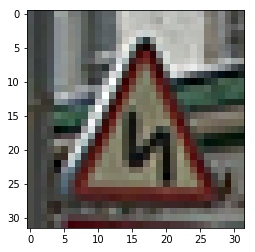

```
['Keep left' 'Turn right ahead' 'Speed limit (50km/h)'
 'Roundabout mandatory' 'Yield']
[  1.00000000e+00   2.11953732e-15   5.40672989e-16   3.02195256e-16
   2.01144120e-17]
```

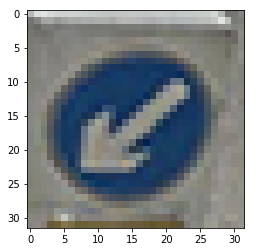

```
['No entry' 'Turn left ahead' 'No passing' 'Priority road' 'No vehicles']
[  9.96863604e-01   3.08717042e-03   4.90879574e-05   9.89153435e-08
   4.94442496e-08]
```

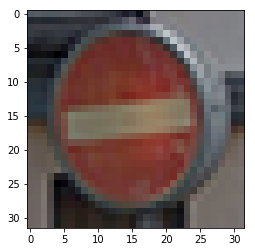

```
['No entry' 'Go straight or right' 'Roundabout mandatory' 'No passing'
 'Speed limit (30km/h)']
[  1.00000000e+00   3.42731243e-09   6.49587128e-14   4.18270137e-16
   3.01797786e-16]
```

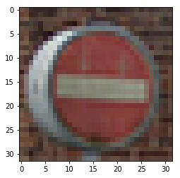

```
['No entry' 'Go straight or right' 'Roundabout mandatory' 'Stop'
 'Keep right']
[  1.00000000e+00   2.88684710e-16   2.10463891e-16   1.21940989e-17
   8.16299116e-20]
```

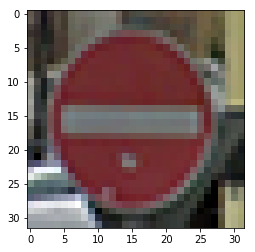

```
['Keep left' 'Road work' 'Bicycles crossing' 'Wild animals crossing'
 'Turn right ahead']
[  1.00000000e+00   2.38288198e-08   9.41777323e-09   1.23767968e-10
   7.40154049e-11]
```

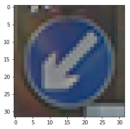

```
['Keep left' 'Bicycles crossing' 'Speed limit (100km/h)' 'Turn right ahead'
 'Speed limit (30km/h)']
[  1.00000000e+00   3.25260565e-08   6.06363937e-09   1.37936595e-09
   7.36828820e-10]
```

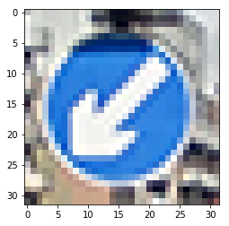

```
['Roundabout mandatory' 'Speed limit (100km/h)' 'Speed limit (120km/h)'
 'No entry' 'Right-of-way at the next intersection']
[  9.94796216e-01   5.20379841e-03   3.25149752e-09   9.70628466e-10
   5.07103040e-11]
```

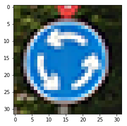

```
['Roundabout mandatory' 'No entry' 'Priority road'
 'End of all speed and passing limits' 'Keep right']
[  9.99999881e-01   1.51048226e-07   2.12776219e-09   1.87868731e-11
   2.70166290e-12]
```

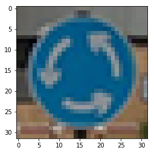

```
['Turn left ahead' 'Stop' 'Roundabout mandatory' 'No vehicles' 'Keep right']
[  1.00000000e+00   7.44292059e-11   2.17078196e-11   3.09447780e-12
   3.03830290e-12]
```

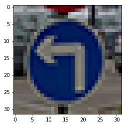

```python
for i in range(len(myoldimg)):
    plt.imshow(cv2.cvtColor(myoldimg[i].astype('uint8'), cv2.COLOR_RGB2BGR))
    print(signname[mytestpredicts[1][i]])
    print(mytestpredicts[0][i])
    plt.show()
```